# Basic growth simulations

Authors

Nicholas Harbour

Markus Owen

Published

July 31, 2024, 11:04:17

Modified

July 31, 2024, 11:03:33

# 1 Simulations of basic tumour growth.

[Preoperative growth dynamics of untreated glioblastoma: Description of an exponential growth type, correlating factors, and association with postoperative survival](https://doi.org/10.1093/noajnl/vdae053)

“Median tumor volume doubling time (VDT) was 31 days, median specific growth rate (SGR) was 2.2% growth per day.” This quote from the paper must use this same relationship: growth rate = $\ln(2)/T2=0.0224/\text{day}==8.16/\text{year}$.

[Patient-specific parameter estimates of glioblastoma multiforme growth dynamics from a model with explicit birth and death rates](https://doi.org/10.3934%2Fmbe.2019265)

Max proliferation rate of about 0.2/day (this is not volumetric growth rate, but proliferation rate) in a reaction diffusion model. This is equal to 73/year.

yang2019 has mean around 20/year.

Key parameters here are going to be: $P_s$, $m_s$, $k$, $\delta_s$, $m_i$ (all the same), $\delta_i$ (the same for $i=1,...,n-1$), $\delta_n$.

This is six key parameters, assuming $k=1$.

## 1.1 Import packages

```python
import numpy as np
import matplotlib.pyplot as plt
import pandas as pd
import scipy.stats as stats
from scipy.stats import lognorm
from numba import jit
```

## 1.2 import functions

all functions are in: “notebooks/gsc_model_functions.py”

```python
import gsc_model_functions as gmf
```

# 2 Calculate Ps_max

Simulate model and calculate the fraction of GSCs to work out reasonable values for Ps.

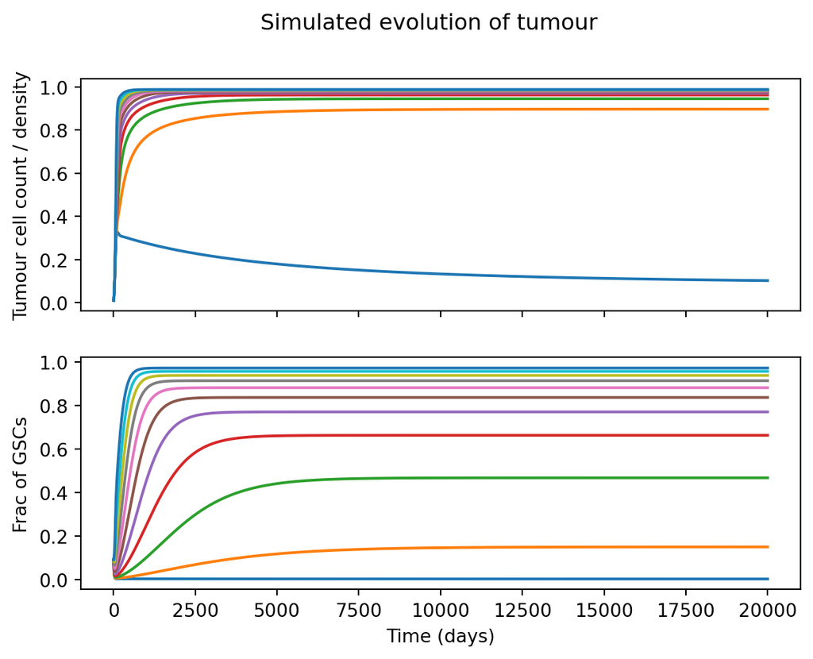

```python
### import params
from gsc_model_params import *

### override some parameters ###
# fixed proliferation rate
# use the mean of the fitted distribution
pro_rate = 20 # per year

lam = 0 # max probability rate in detection & death, in this simulation we do want to simulate detection/death so set it to 0

s0 = 0.001 # initial GSCs

u0 = np.zeros((1,n+1))
u0[0] = s0

dt = 0.1
rad_on = 0 # no RT
BMP4_on = 0 # no BMP4
resect_on = 0   # no resection

## core parameters
mv = mv_rho_scale*np.ones(n)*pro_rate
ms = ms_mv_scale*mv[0]
mv[n-1] = 0

# calc alpha as proportional to rho
alpha = gmf.calc_alpha_from_rho(pro_rate)
beta = gmf.calc_beta(alpha)

Ps_list = np.linspace(0.505,0.9,11) # try a range of Ps_max values

save_frac_GSC = np.zeros(len(Ps_list)) # store frac of GSCs at steady state for each value of Ps
save_final_N = np.zeros(len(Ps_list)) # store the total tumour size at the final time to ensure carrying capacity has been reached
t_final = 20000

random_seed = 1

j = 0

fig, (ax1,ax2) = plt.subplots(2, sharex=True)

for Ps_max in Ps_list:
    u,N,VS,t,m,B,detect_size,detect_t,tp1,tp2 = gmf.simulate_model(t_final,dt,u0,psi,Ps_max,Ps_min,n,k,ms,mv,delta_s,delta_v,delta_m,delta_b,C,u_s,n_RT_repeat,n_RT_cycles,rad_on,alpha,beta,eta,mu,t_RT_wait,t_RT_interval,detect_threshold,detection_sensitivity,death_sensitivity,lam,resection_to_RT_delay,BMP4_on,death_threshold,resect_on,resect_fraction,random_seed)
    # only store steady state if the rate of change is sufficiently small
    if abs(u[-1,0]/N[-1] - u[-2,0]/N[-2])/dt < 1e-5:
      save_frac_GSC[j] = u[-1,0]/N[-1]
      save_final_N[j] = N[-1]
    j = j + 1

    ax1.plot(t,N)
    ax1.set(ylabel="Tumour cell count / density")
    fig.suptitle("Simulated evolution of tumour")

    ax2.set(ylabel="Frac of GSCs")
    ax2.plot(t,u[:,0]/N)
    ax2.set(xlabel="Time (days)")
```

Plot the results of frac GSCs and total tumour volume together

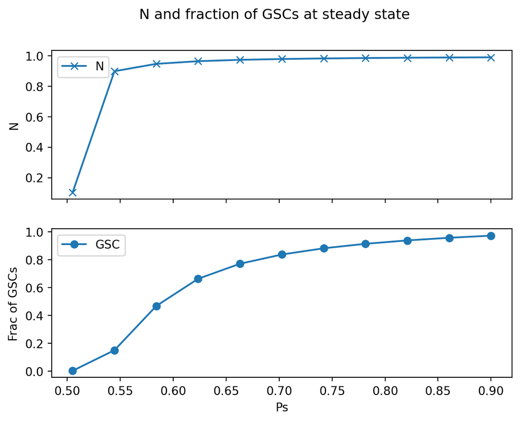

```python
fig, (ax1,ax2) = plt.subplots(2, sharex=True)

ax1.plot(Ps_list,save_final_N,'x-')
ax1.set(ylabel="N")
ax1.legend(['N'])

ax2.plot(Ps_list,save_frac_GSC,'o-')
ax2.set(xlabel="Ps")
ax2.set(ylabel="Frac of GSCs")
ax2.legend(['GSC'])

fig.suptitle("N and fraction of GSCs at steady state")
plt.show()
```

plot only the frac of GSCs

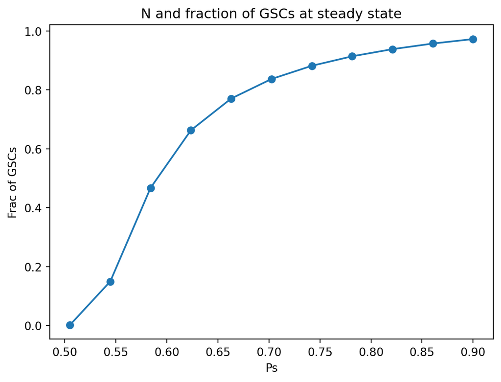

Figure 3: As We increase $P_s$ the fraction of GSCs increases.

```python
plt.plot(Ps_list,save_frac_GSC,'o-')
plt.xlabel("Ps")
plt.ylabel("Frac of GSCs")
plt.title("N and fraction of GSCs at steady state")
plt.show()
```

For our chosen value of Ps_max simulate the model

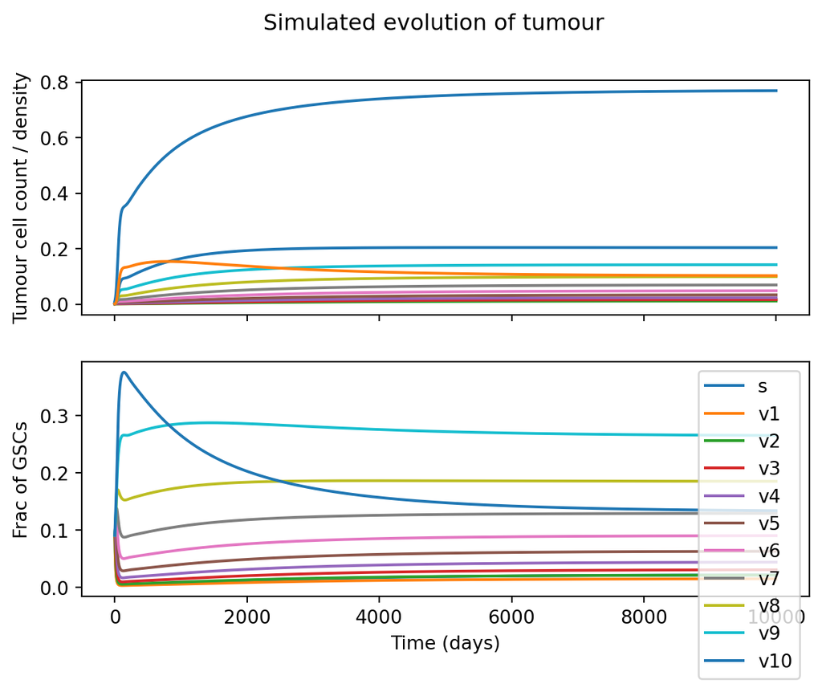

```python
Ps_max = 0.52
t_final = 10000
u,N,VS,t,m,B,detect_size,detect_t,tp1,tp2 = gmf.simulate_model(t_final,dt,u0,psi,Ps_max,Ps_min,n,k,ms,mv,delta_s,delta_v,delta_m,delta_b,C,u_s,n_RT_repeat,n_RT_cycles,rad_on,alpha,beta,eta,mu,t_RT_wait,t_RT_interval,detect_threshold,detection_sensitivity,death_sensitivity,lam,resection_to_RT_delay,BMP4_on,death_threshold,resect_on,resect_fraction,random_seed)

fig, (ax1,ax2) = plt.subplots(2, sharex=True)

ax1.plot(t,N)
ax1.plot(t,u[:,])
ax1.set(ylabel="Tumour cell count / density")
fig.suptitle("Simulated evolution of tumour")

ax2.set(ylabel="Frac of GSCs")
ax2.plot(t,u[:,0]/N,label='s')
for i in range(1,n+1) :
    ax2.plot(t,u[:,i]/N,label='v'+str(i))
ax2.set(xlabel="Time (days)")
ax2.legend()
```

# 3 Explore link between full and reduced model

Initialise arrays, etc.

```python
Ps = Ps_max
t_final = 20000
dt = 0.1

t = np.arange(0, t_final+dt, dt)
nt = len(t)

u = np.zeros((nt,n+1))
VS = np.zeros(nt)
N = np.zeros(nt)

# define IC
n0 = 0.001
s0 = 0.01*n0 # fraction of initial tumour
v_ratio = 1.95 # ratio between successive compartments
v0 = ((n0-s0)*(v_ratio-1)/(v_ratio**n-1))*(v_ratio**np.arange(n))
u0 = np.zeros(n+1)
u0[0] = s0
u0[1:] = v0


# u[0,0] = s0
u[0,:] = u0
VS[0] = np.sum(u[0,1:n+1]) # sum the 1th to nth entries
N[0] = u[0,0] + VS[0]

for i in range(nt-1):

        u[i+1,:] = u[i,:] + dt * gmf.gsc_model_dudt(u[i,:],n,Ps,k,ms,mv,delta_s,delta_v)

        VS[i+1] = np.sum(u[i+1,1:n+1])
        N[i+1] = u[i+1,0] + VS[i+1]
```

Run reduced model. It should have equivalent steady states to the full model.

```python
t_final = 20000
dt = 0.1
t_reduced = np.arange(0, t_final+dt, dt)
nt_reduced = len(t_reduced)

u_reduced = np.zeros((nt_reduced,2))
VS_reduced = np.zeros(nt_reduced)
N_reduced = np.zeros(nt_reduced)
vi_reconstructed = np.zeros((nt_reduced,n))

# define IC
u_reduced[0,0] = s0
VS_reduced[0] = u_reduced[0,0]
N_reduced[0] = u[0,0] + VS_reduced[0]

for i in range(nt_reduced-1):

        u_reduced[i+1,:] = u_reduced[i,:] + dt * gmf.gsc_model_reduced_dudt(u_reduced[i,:],n,Ps,k,ms,mv,delta_s,delta_v)

        VS_reduced[i+1] = u_reduced[i+1,1]
        N_reduced[i+1] = u_reduced[i+1,0] + VS_reduced[i+1]
```

Reconstruct full model trajectories as if the reduction were exact (which it should be at steady state).

```python
vi_reconstructed[:,0] = gmf.alpha_1(N_reduced,mv,k,delta_v,n)*VS_reduced
for i in range(1,n):
  vi_reconstructed[:,i] = gmf.alpha_i(N_reduced,mv,k,delta_v,i)*vi_reconstructed[:,i-1]
```

Plot full model results.

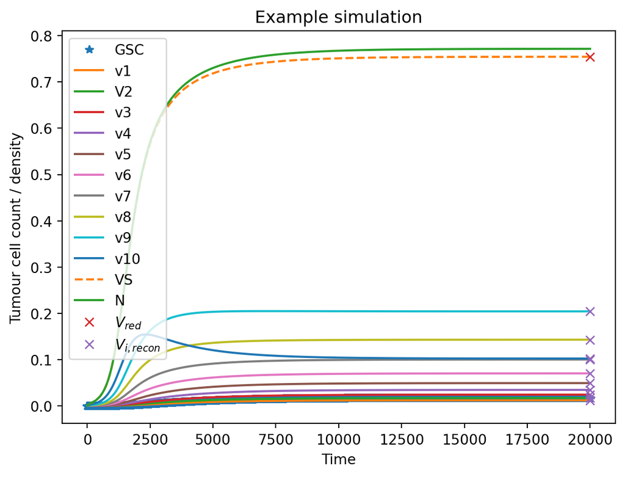

```python
plt.figure()
plt.plot(t,u[:,0],'*')
plt.plot(t,u[:,1:n+1])
plt.plot(t,VS,'--')
plt.plot(t,N)
plt.plot(t[-1],VS_reduced[-1],'x')
plt.plot(t[-1]*np.ones(n),np.squeeze(vi_reconstructed[-1:,]),'x')
plt.xlabel("Time")
plt.ylabel("Tumour cell count / density")
plt.title("Example simulation")
plt.legend(["GSC", "v1", "V2", "v3","v4", "v5", "v6", "v7", "v8", "v9", "v10", "VS", "N", r"$V_{red}$", r"$V_{i,recon}$"])
plt.show()
```

We see that in the case when we have 10 generations the GSCs are kept at much lower numbers as is the case in: https://aacrjournals.org/cancerres/article/73/5/1481/586464/Acute-and-Fractionated-Irradiation-Differentially

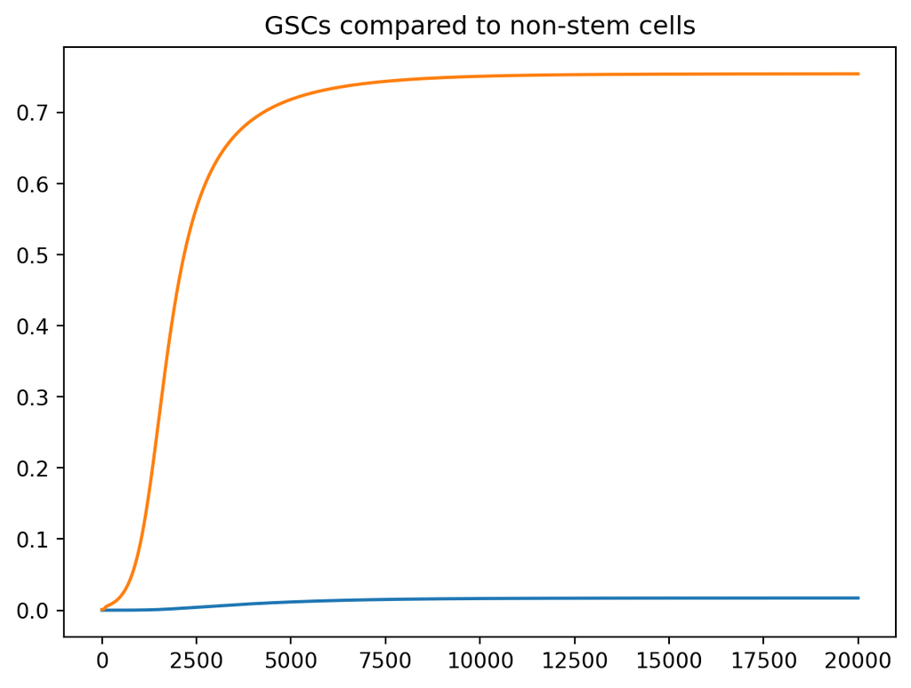

```python
plt.figure()
plt.plot(t,u[:,0])
plt.plot(t,VS)
plt.title("GSCs compared to non-stem cells")
```

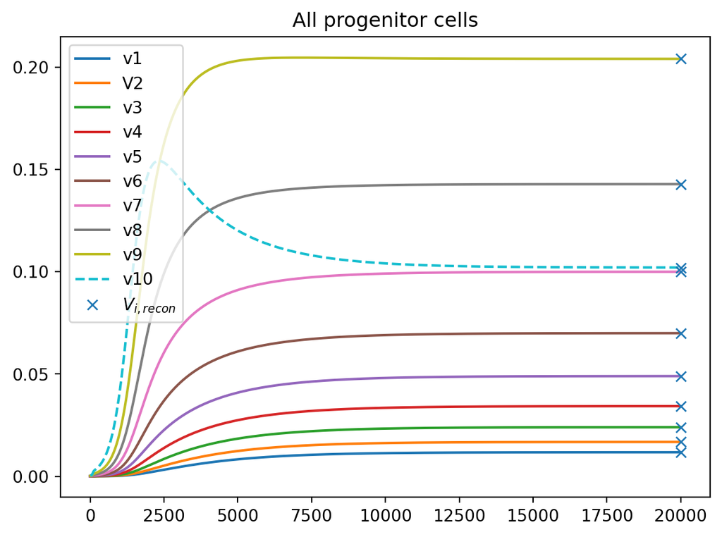

```python
plt.figure()
plt.plot(t,u[:,1:n])
plt.plot(t,u[:,n],'--')
plt.plot(t[-1]*np.ones(n),np.squeeze(vi_reconstructed[-1:,]),'x')
plt.legend([ "v1", "V2", "v3","v4", "v5", "v6", "v7", "v8", "v9", "v10", r"$V_{i,recon}$"])
plt.title("All progenitor cells")
plt.show()
```

Plot reduced model results and comparison with full model.

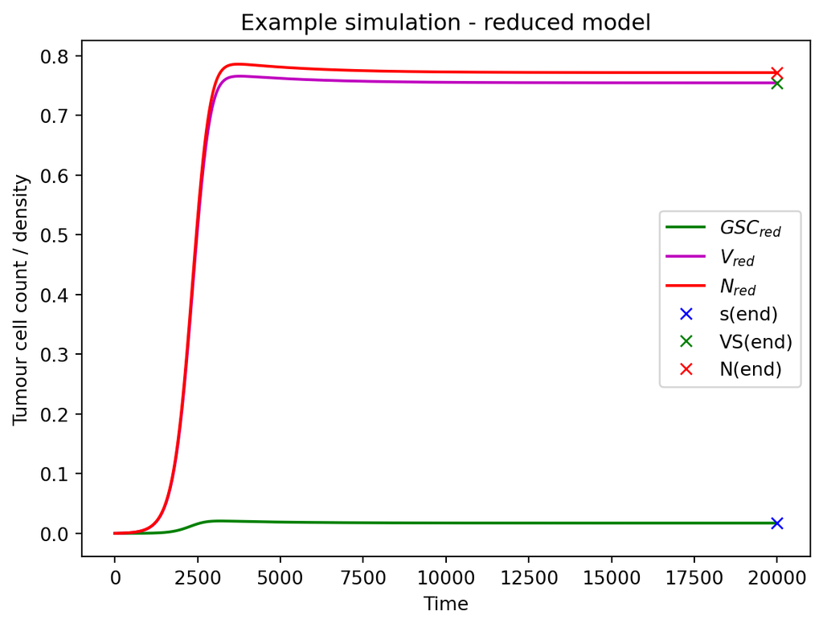

```python
plt.figure()
plt.plot(t_reduced,u_reduced[:,0],'g')
plt.plot(t_reduced,VS_reduced,'m')
plt.plot(t_reduced,N_reduced,'r')
plt.plot(t_reduced[-1],u[-1,0],'bx')
plt.plot(t_reduced[-1],VS[-1],'gx')
plt.plot(t_reduced[-1],N[-1],'rx')
plt.xlabel("Time")
plt.ylabel("Tumour cell count / density")
plt.title("Example simulation - reduced model")
plt.legend([r"$GSC_{red}$", r"$V_{red}$", r"$N_{red}$", "s(end)", "VS(end)", "N(end)"])
plt.show()
```

Plot nullclines for the reduced model.

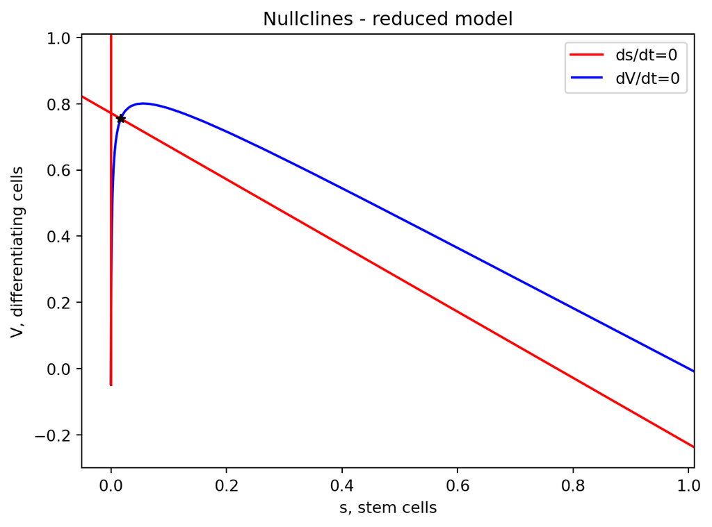

```python
srange = np.linspace(-0.05*k, 1.01*k, 101)
Vrange = np.linspace(-0.05*k, 1.01*k, 101)
s, V = np.meshgrid(srange,Vrange)

cntrV = plt.contour(s, V, gmf.gsc_model_reduced_dVdt(s,V,n,Ps,k,ms,mv,delta_s,delta_v), [0], colors = 'b')
h,_ = cntrV.legend_elements()
dsdt1 = plt.plot(0*srange,Vrange,'-r')
dsdt2 = plt.plot(srange,(1-delta_s/((2*Ps-1)*ms))*k-srange,'-r')
plt.plot(u_reduced[-1,0],VS_reduced[-1],'*k')
plt.xlabel("s, stem cells")
plt.ylabel("V, differentiating cells")
plt.title("Nullclines - reduced model")
plt.legend([dsdt1[0],h[0]],['ds/dt=0','dV/dt=0'])
plt.show()
```

Zoom in nearer the intersection / steady state.

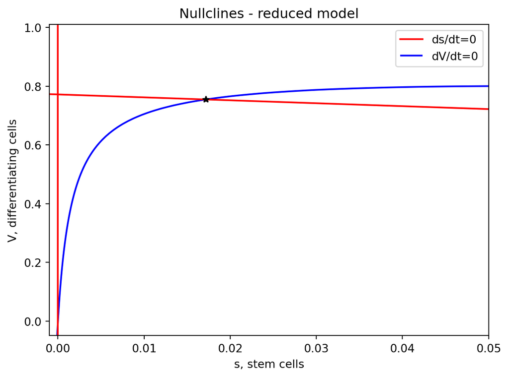

```python
srange = np.linspace(-0.001*k, 0.05*k, 101)
Vrange = np.linspace(-0.05*k, 1.01*k, 101)
s, V = np.meshgrid(srange,Vrange)

cntrV = plt.contour(s, V, gmf.gsc_model_reduced_dVdt(s,V,n,Ps,k,ms,mv,delta_s,delta_v), [0], colors = 'b')
h,_ = cntrV.legend_elements()
dsdt1 = plt.plot(0*srange,Vrange,'-r')
dsdt2 = plt.plot(srange,(1-delta_s/((2*Ps-1)*ms))*k-srange,'-r')
plt.plot(u_reduced[-1,0],VS_reduced[-1],'*k')
plt.xlabel("s, stem cells")
plt.ylabel("V, differentiating cells")
plt.title("Nullclines - reduced model")
plt.legend([dsdt1[0],h[0]],['ds/dt=0','dV/dt=0'])
plt.show()
```